# Notes on Ch 10: EDA

## Visualizing two categorical variables

- using `geom_count()`:

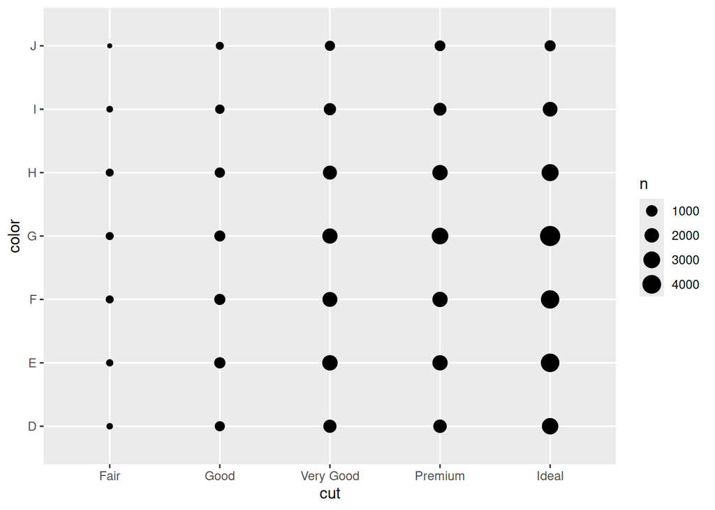

```r
ggplot(diamonds, aes(x = cut, y = color)) +
  geom_count()
```

- the size of the circles depends on the number of observations that occurred for each combination of values (cut and color)

Counting first the using `geom_tile()`:

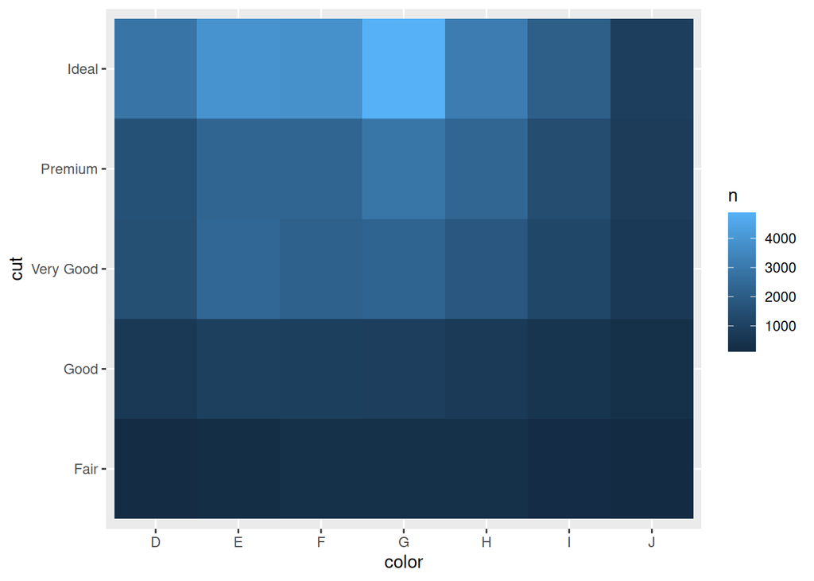

```r
diamonds |>
  count(color, cut) |>
  ggplot(aes(x = color, y = cut)) +
  geom_tile(aes(fill = n))
```

- This is a heatmap.

## Exercises

E1. How could you rescale the count dataset above to more clearly show the distribution of cut within color, or color within cut?

E2. What different data insights do you get with a segmented bar chart if color is mapped to the x aesthetic and cut is mapped to the fill aesthetic? Calculate the counts that fall into each of the segments.

E3. Use `geom_tile()` together with dplyr to explore how average flight departure delays vary by destination and month of year. What makes the plot difficult to read? How could you improve it?

## Two numerical variables

- with a scatterplot:

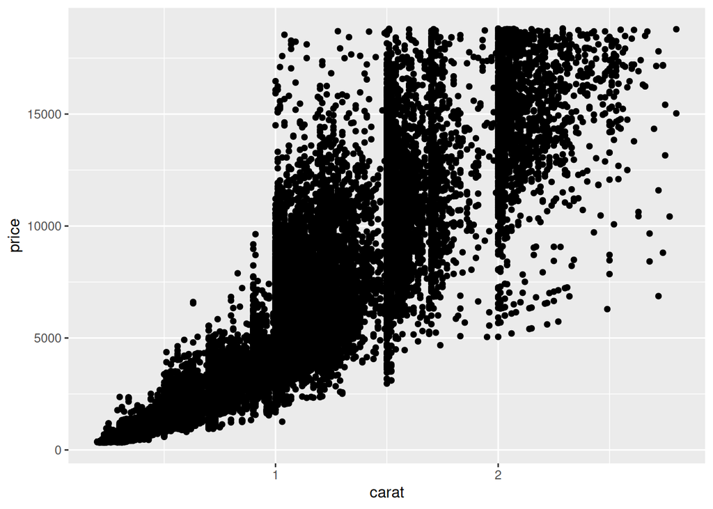

```r
ggplot(smaller, aes(x = carat, y = price)) +
  geom_point()
```

- scatterplot with transparency (alpha):

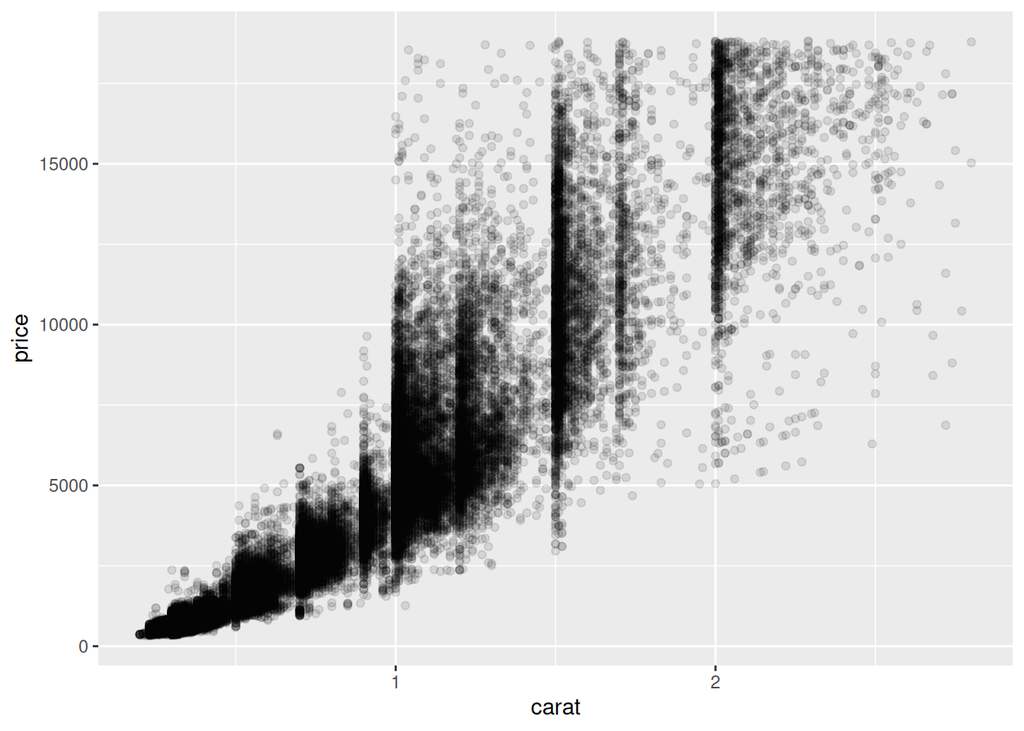

```r
ggplot(smaller, aes(x = carat, y = price)) +
  geom_point(alpha = 0.1)
```

- using `geom_bin2d()`

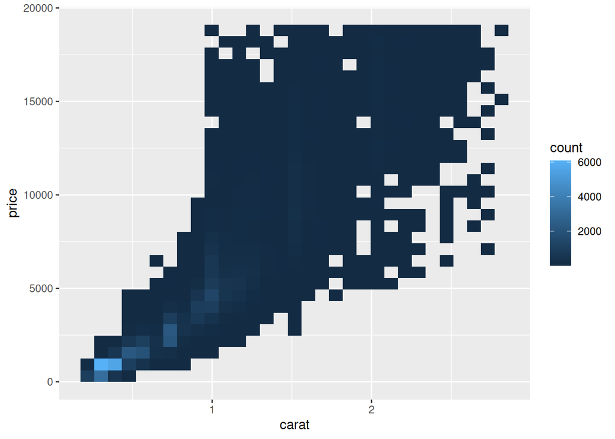

```r
ggplot(smaller, aes(x = carat, y = price)) +
  geom_bin2d()
```

- using `geom_hex()`:

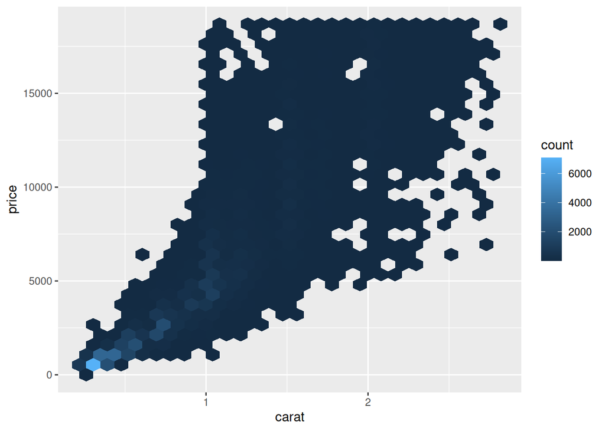

```r
ggplot(smaller, aes(x = carat, y = price)) +
  geom_hex()
```

- binning one continuous variable so it acts like a categorical variable:

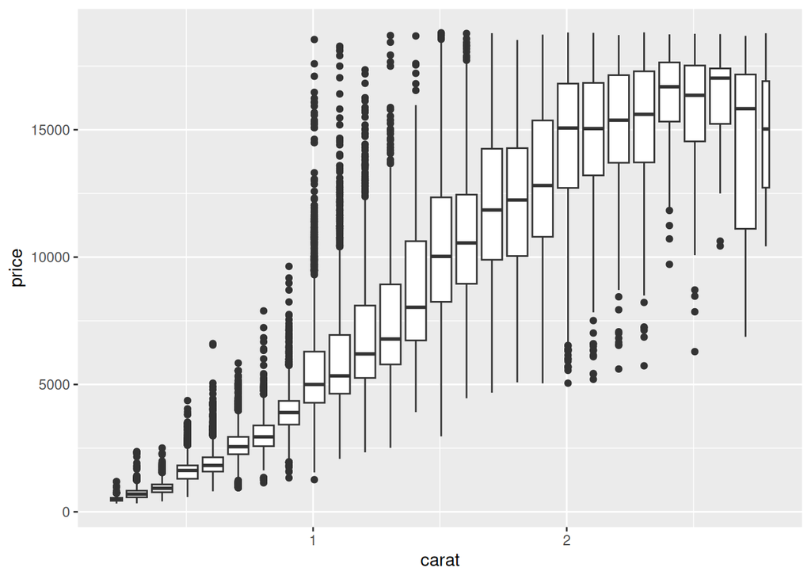

```r
ggplot(smaller, aes(x = carat, y = price)) +
  geom_boxplot(aes(group = cut_width(carat, 0.1)))
```

The function `cut_width(x, width)` divides `x` into bins of width `width`.

## Exercises

E1. Instead of summarizing the conditional distribution with a boxplot, you could use a frequency polygon. What do you need to consider when using cut_width() vs. cut_number()? How does that impact a visualization of the 2d distribution of carat and price?

E2. Visualize the distribution of carat, partitioned by price.

E3. How does the price distribution of very large diamonds compare to small diamonds? Is it as you expect, or does it surprise you?

E4. Combine two of the techniques you’ve learned to visualize the combined distribution of cut, carat, and price.

E5. Two dimensional plots reveal outliers that are not visible in one dimensional plots. For example, some points in the following plot have an unusual combination of x and y values, which makes the points outliers even though their x and y values appear normal when examined separately. Why is a scatterplot a better display than a binned plot for this case?

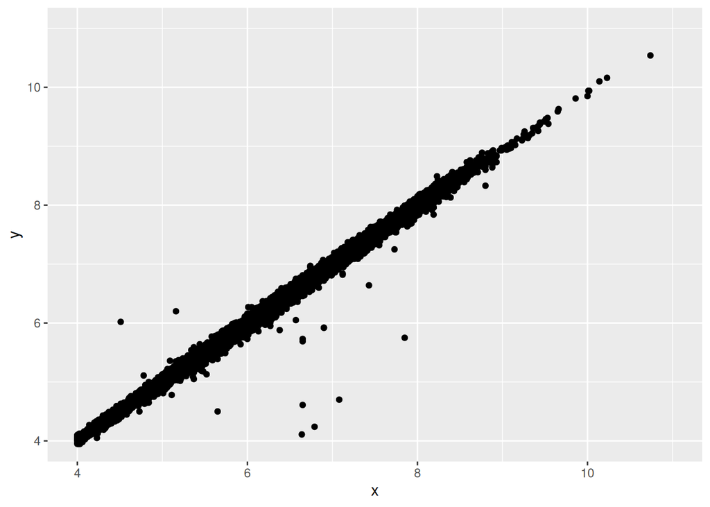

```r
diamonds |>
  filter(x >= 4) |>
  ggplot(aes(x = x, y = y)) +
  geom_point() +
  coord_cartesian(xlim = c(4, 11), ylim = c(4, 11))
```

Ans. With a scatterplot, it is easier to visually compare one dot against the rest of dots. Binning will take away some of this feature, because by doing so, we will be comparing one data point against the contents of the bin it happens to belong to. This is also useful, but less “powerful” when used to visually inspect the data for outliers.

E6. Instead of creating boxes of equal width with cut_width(), we could create boxes that contain roughly equal number of points with cut_number(). What are the advantages and disadvantages of this approach?

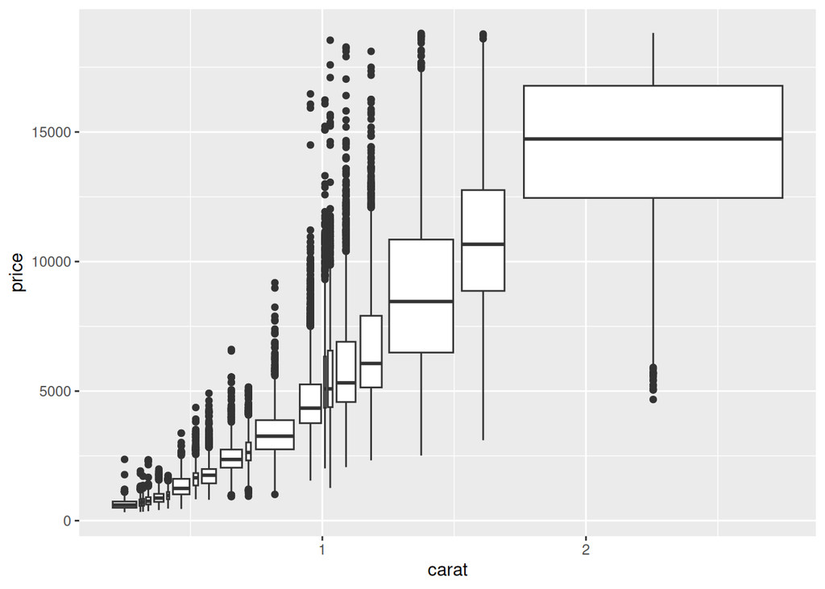

```r
ggplot(smaller, aes(x = carat, y = price)) +
  geom_boxplot(aes(group = cut_number(carat, 20)))
```

Ans. `cut_number()`, cuts the vector into intervals containing equal number of points. Depending on the distribution of data, this can end up line the graph above, where the width of each boxplot is not similar.

## Patterns and models

Ask: - Could the pattern be due to coincidence? - How can you describe the relationship implied by the pattern? - How strong is the relationship implied by the pattern? - Does the relationship change if you look at individual subgroups of the data?

Modeling Example Fitting a model that predicts `price` from `carat` and then computes the residuals aka the difference between the predicted value and the actual value:

```r
library(tidymodels)
```

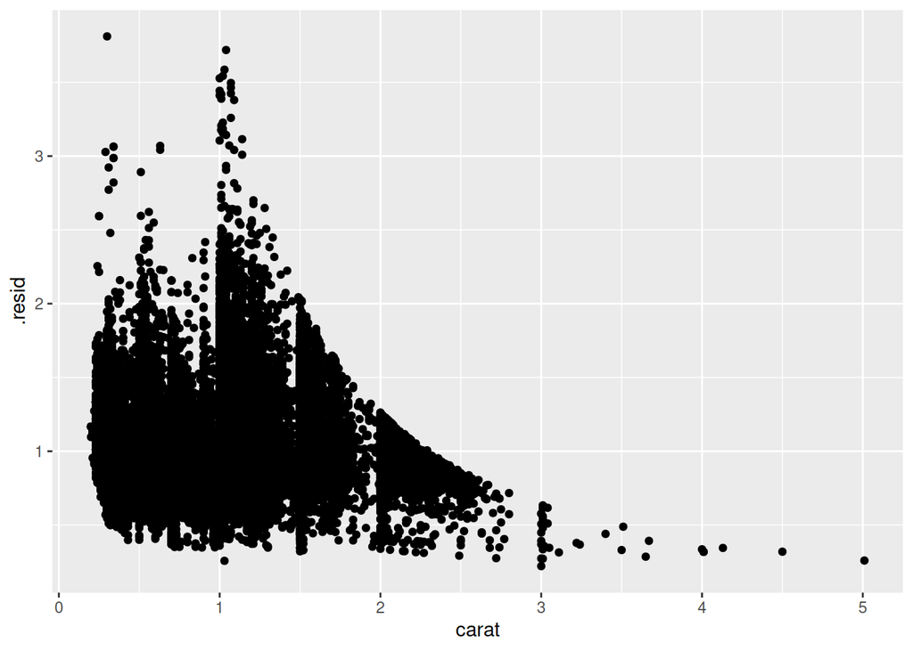

```r
diamonds <- diamonds |>
  mutate(
    log_price = log(price),
    log_carat = log(carat)
  )

diamonds_fit <- linear_reg() |>
  fit(log_price ~ log_carat, data = diamonds)

diamonds_aug <- augment(
  diamonds_fit, new_data = diamonds
) |>
  mutate(.resid = exp(.resid))

ggplot(diamonds_aug, aes(x = carat, y = .resid)) +
  geom_point()
```

The relationship between cut and price relative to size can be visualized with this boxplot:

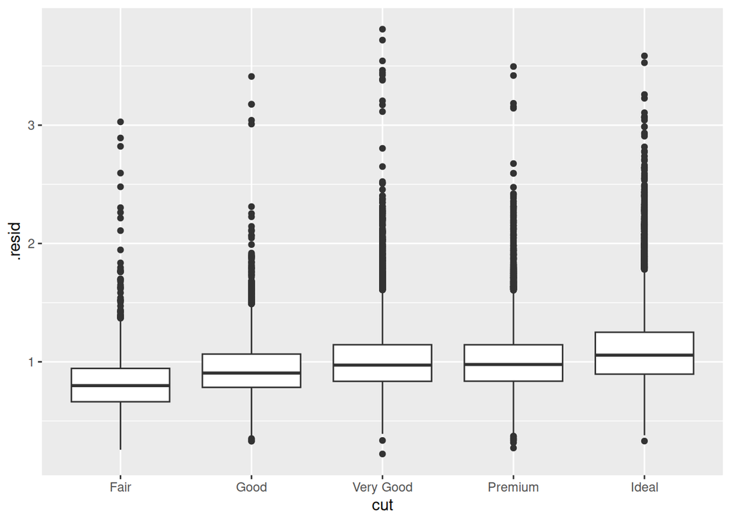

```r
ggplot(diamonds_aug, aes(x = cut, y = .resid)) +
  geom_boxplot()
```